# miRNA

Jess Hoffman

2/2/2022

# Alignment

- Novogene: Sequencing from small RNAseq performed at Novogene were aligned using the Illumina Basespace platform:
  - Adapters trimmed, reads filtered to 18-51 length (with reads passing the FASTQ Toolkit filter)
  - Reads were aligned (HG19, MiRBase21), and hits were determined using the small RNA app.
- Yerkes: Small RNAseq performed at Emory Yerkes Nonhuman Primate Genomics core were aligned and hits were determined using the Qiagen GeneGlobe console with QIAseq miRNA Quantification tool.

# Read in Files

```r
options("scipen"=2, "digits"=3)
library(tidyverse)
setwd("/Volumes/davis-lab/Jess Hoffman/11. Big Seq/11. For Paper/FinalR")
fullmiRNAcounts = read.csv("/Volumes/davis-lab/Jess Hoffman/11. Big Seq/11. For Paper/FinalR/miRNA_counts.csv", header = TRUE) %>% column_to_rownames("miR")
source = fullmiRNAcounts[1,]
miRNAcounts = fullmiRNAcounts[2:nrow(fullmiRNAcounts),] %>% mutate_if(is.character,as.numeric);
rownames(miRNAcounts) = rownames(fullmiRNAcounts)[2:nrow(fullmiRNAcounts)]

cell = miRNAcounts %>% dplyr::select(starts_with("C")); head(cell)
```

```
##                  C1004 C1006  C1007  C1063  C1097  C1099 C2013  C2016   C894
## hsa-let-7a-5p   107465 84879 163970 251046 166261 154819 22242 171669 235011
## hsa-let-7a-3p       36     4     50     90     33     50     4     32     90
## hsa-let-7a-2-3p     20    13     81    120     70     58     9     57    116
## hsa-let-7b-5p    29564 21448  40033  45088  47222  31921  3789  16015  65213
## hsa-let-7b-3p       14    19     18     64     15      4     1      9     33
## hsa-let-7c-5p     3365  2983   2910   4395   3581   3623   490   2160   1432
##                   C925   C930   C938   C975   C924  C1010  C1066   C956   C957
## hsa-let-7a-5p   111954 198424 131132 182676 162064 168220 176544 205340 383938
## hsa-let-7a-3p       54     78     29     30      9      9     37     50     93
## hsa-let-7a-2-3p     49    185    148      0      0      0      0      0      0
## hsa-let-7b-5p    28967  23525  38384 108033 119507  76999 126366 166295 257166
## hsa-let-7b-3p       25     22     43    119     57    111    123    150    174
## hsa-let-7c-5p     2571   4851   1791   3759    375   2807   2456   4373   5685
##                   C903   C926  C1045   C902  C1050  C1095   C896  C1092  C1100
## hsa-let-7a-5p   435623 295050 403898 366044 293761 423080 148144 500709 363065
## hsa-let-7a-3p       22     17    104    125     33     37     57     77    106
## hsa-let-7a-2-3p      0      0      0      0      0      0      0      0     62
## hsa-let-7b-5p   273428 267463 220018 286638 122769 292737 170799 371037 280955
## hsa-let-7b-3p      259    159    253    161    160    223    110    285    279
## hsa-let-7c-5p     5772   1298   7789   4629   4996   7979    962   5261   7386
##                   C985  C1048  C1083
## hsa-let-7a-5p   536618 230362 843784
## hsa-let-7a-3p      145      6    104
## hsa-let-7a-2-3p      5      0      1
## hsa-let-7b-5p   198769 159752 334534
## hsa-let-7b-3p      305    131    464
## hsa-let-7c-5p    15724   2128  19941
```

```r
EV = miRNAcounts %>% dplyr::select(starts_with("E")); head(EV)
```

```
##                 E1004 E1006 E1045 E1050 E1095 E1099 E2013  E903  E956  E902
## hsa-let-7a-5p    2392  5585  4929  6571  1520  5374  2533  6224  4962  5981
## hsa-let-7a-3p       4     1     2     0     0     0     0     0     0    18
## hsa-let-7a-2-3p     0     0     5     2     0     7     0     1     2   136
## hsa-let-7b-5p   16325 29967 54845 10257 22178 29923  7937 10715 13308 35734
## hsa-let-7b-3p       0     6     5     1     3    15     7     4     5    18
## hsa-let-7c-5p    2886  6326 13754  1431  2997  5027  1193  1061  3259  1124
##                 E894  E896 E1097 E1063 E1066  E930 E1007  E924 E1010  E975
## hsa-let-7a-5p   2425 25512  3593   514  1436  6472  3049 10402  5678  9088
## hsa-let-7a-3p    158    74    12     0    29    66    81    61    65    60
## hsa-let-7a-2-3p  152   230    24     0    71   110   129    84    48    85
## hsa-let-7b-5p   7759 77378 10895   999  5223 10348  9688 40234 16276 32830
## hsa-let-7b-3p     31    31     4     0    15    32     9    30    22    22
## hsa-let-7c-5p    250   884   442     5   287   920   284   500  1324   990
##                 E1083 E925  E957 E926 E2016 E1100  E985
## hsa-let-7a-5p    1266 1521  9173 2850  1600 23584 23029
## hsa-let-7a-3p      51   87    33   70    78    43     0
## hsa-let-7a-2-3p    67  134    75  136   148   182   118
## hsa-let-7b-5p    1511 2393 19062 5236  3139 33801 52699
## hsa-let-7b-3p       4   43    27   27     7    57    20
## hsa-let-7c-5p     127  769   598  508   229  2738  2827
```

```r
paste("Number of Cell Samples - ", dim(cell)[2])
```

```
## [1] "Number of Cell Samples -  30"
```

```r
paste("Number of EV Samples - ", dim(EV)[2])
```

```
## [1] "Number of EV Samples -  27"
```

```r
# Read in patient data
info = read.csv("/Volumes/davis-lab/Jess Hoffman/11. Big Seq/11. For Paper/FinalR/PatientInfo.csv", header = TRUE)
colnames(info) = c("Patient","Age (months)", "Age Group", "Sex", "Diagnosis", "miRNA_Cell", "miRNA_EV", "Total_Cell","Total_EV"); info
```

```
##    Patient Age (months) Age Group  Sex
## 1      894            6    infant <NA>
## 2      896           12     child    F
## 3      902           48     child    M
## 4      903            0   neonate    F
## 5      924            2    infant    M
## 6      925            0   neonate    F
## 7      926           14     child    M
## 8      930            0   neonate    M
## 9      938           60     child    M
## 10     956            5    infant    F
## 11     957            7    infant    M
## 12     975            6    infant    M
## 13     985            0   neonate    M
## 14    1004           12     child    M
```

[output cut: 78 more lines]

# Filter reads

```r
paste("Cellular # miRNAs - ", dim(cell)[1])
```

```
## [1] "Cellular # miRNAs -  2593"
```

```r
cell_filter = cell[apply(cell == 0, 1, sum) <= 10, ] # 10 = number to # of zeros allowed
cell_filter = cell_filter[complete.cases(cell_filter), ] # remove NAs
paste("Cellular # miRNAs after filter - ", dim(cell_filter)[1])
```

```
## [1] "Cellular # miRNAs after filter -  206"
```

```r
paste("EV # miRNAs - ", dim(EV)[1])
```

```
## [1] "EV # miRNAs -  2593"
```

```r
EV_filter = EV[apply(EV == 0, 1, sum) <= 10, ] #change number to # of zeros allowed
EV_filter = EV_filter[complete.cases(EV_filter), ] # remove NAs
paste("EV # miRNAs after filter - ", dim(EV_filter)[1])
```

```
## [1] "EV # miRNAs after filter -  641"
```

```r
# Figure 3A
paste("# miRNAs in EV and Cell - ", length(intersect(rownames(EV_filter), rownames(cell_filter))))
```

```
## [1] "# miRNAs in EV and Cell -  193"
```

```r
paste("# miRNAs in EV, not Cell - ",length(setdiff(rownames(EV_filter), rownames(cell_filter))))
```

```
## [1] "# miRNAs in EV, not Cell -  448"
```

```r
paste("# miRNAs in Cell, not Cell - ",length(setdiff(rownames(cell_filter), rownames(EV_filter))))
```

```
## [1] "# miRNAs in Cell, not Cell -  13"
```

```r
#combine after filter - 193 miRNAs in intersect
merged_filteredcounts = merge(cell_filter,EV_filter,by=0) %>% column_to_rownames("Row.names"); dim(merged_filteredcounts)
```

```
## [1] 193  57
```

# Build edgeR object - Cell and EV combined

1. compile patient info
2. build edgeR object of filtered counts, perform normalization with the trimmed mean of M-values method, log transform counts per million –> logcpm
3. Remove batch effect with ComBat
4. PCA before and after batch correction

```r
library(edgeR)
library(sva)
# Patient info
coldata = data.frame(Type = str_sub(colnames(merged_filteredcounts),1,1),
                     Patient = as.numeric(str_sub(colnames(merged_filteredcounts),2,-1)))
coldata = left_join(coldata,info[,c(1:4,6:7)])
coldata$Batch = if_else(coldata$Type == "C", coldata$miRNA_Cell, coldata$miRNA_EV); coldata = coldata[,c(1:5,8)]
coldata = coldata %>% mutate(across(.cols = c(1:2,4:6), .fns = factor))
coldata$logmonths = ifelse(log10(coldata$`Age (months)`)<0, 0, log10(coldata$`Age (months)`))
rownames(coldata) = colnames(merged_filteredcounts)
coldata
```

```
##       Type Patient Age (months) Age Group  Sex    Batch logmonths
## C1004    C    1004           12     child    M Novogene     1.079
## C1006    C    1006            6    infant    F Novogene     0.778
## C1007    C    1007            6    infant    M Novogene     0.778
## C1063    C    1063           36     child    M Novogene     1.556
## C1097    C    1097            3    infant    M Novogene     0.477
## C1099    C    1099            5    infant    F Novogene     0.699
## C2013    C    2013            3    infant    M Novogene     0.477
## C2016    C    2016            0   neonate    F Novogene     0.000
## C894     C     894            6    infant <NA> Novogene     0.778
## C925     C     925            0   neonate    F Novogene     0.000
## C930     C     930            0   neonate    M Novogene     0.000
## C938     C     938           60     child    M Novogene     1.778
## C975     C     975            6    infant    M   Yerkes     0.778
## C924     C     924            2    infant    M   Yerkes     0.301
## C1010    C    1010            2    infant    M   Yerkes     0.301
## C1066    C    1066            6    infant    F   Yerkes     0.778
## C956     C     956            5    infant    F   Yerkes     0.699
## C957     C     957            7    infant    M   Yerkes     0.845
## C903     C     903            0   neonate    F   Yerkes     0.000
## C926     C     926           14     child    M   Yerkes     1.146
## C1045    C    1045            0   neonate    F   Yerkes     0.000
## C902     C     902           48     child    M   Yerkes     1.681
## C1050    C    1050            0   neonate    F   Yerkes     0.000
## C1095    C    1095            3    infant    M   Yerkes     0.477
## C896     C     896           12     child    F   Yerkes     1.079
## C1092    C    1092           48     child    F   Yerkes     1.681
## C1100    C    1100            0   neonate    F   Yerkes     0.000
## C985     C     985            0   neonate    M   Yerkes     0.000
## C1048    C    1048           72     child    F   Yerkes     1.857
## C1083    C    1083            0   neonate    F   Yerkes     0.000
## E1004    E    1004           12     child    M Novogene     1.079
## E1006    E    1006            6    infant    F Novogene     0.778
## E1045    E    1045            0   neonate    F Novogene     0.000
## E1050    E    1050            0   neonate    F Novogene     0.000
## E1095    E    1095            3    infant    M Novogene     0.477
## E1099    E    1099            5    infant    F Novogene     0.699
## E2013    E    2013            3    infant    M Novogene     0.477
## E903     E     903            0   neonate    F Novogene     0.000
## E956     E     956            5    infant    F Novogene     0.699
## E902     E     902           48     child    M   Yerkes     1.681
## E894     E     894            6    infant <NA>   Yerkes     0.778
## E896     E     896           12     child    F   Yerkes     1.079
## E1097    E    1097            3    infant    M   Yerkes     0.477
## E1063    E    1063           36     child    M   Yerkes     1.556
## E1066    E    1066            6    infant    F   Yerkes     0.778
## E930     E     930            0   neonate    M   Yerkes     0.000
## E1007    E    1007            6    infant    M   Yerkes     0.778
## E924     E     924            2    infant    M   Yerkes     0.301
## E1010    E    1010            2    infant    M   Yerkes     0.301
## E975     E     975            6    infant    M   Yerkes     0.778
## E1083    E    1083            0   neonate    F   Yerkes     0.000
## E925     E     925            0   neonate    F   Yerkes     0.000
## E957     E     957            7    infant    M   Yerkes     0.845
## E926     E     926           14     child    M   Yerkes     1.146
## E2016    E    2016            0   neonate    F   Yerkes     0.000
## E1100    E    1100            0   neonate    F   Yerkes     0.000
## E985     E     985            0   neonate    M   Yerkes     0.000
```

```r
# Make edgeR object
dge = DGEList(counts = merged_filteredcounts, group = coldata$Type)
keep = filterByExpr(dge)
table(keep) # Use filterByExpr with default params
```

```
## keep
## TRUE
##  193
```

```r
dge = calcNormFactors(dge, method = "TMM") # TMM normalization
dge$samples
```

```
##       group lib.size norm.factors
## C1004     C  2825875        0.516
## C1006     C  1616248        0.579
## C1007     C  3279589        0.703
## C1063     C  3848324        0.690
## C1097     C  3076827        0.568
## C1099     C  2713544        0.598
## C2013     C   554698        0.634
## C2016     C  2649121        0.554
## C894      C  4128517        0.630
## C925      C  1954460        0.626
## C930      C  4134077        0.690
## C938      C  2757225        0.764
## C975      C   762746        0.670
## C924      C   642268        0.914
## C1010     C   785570        0.835
## C1066     C   709334        0.814
## C956      C   896034        0.667
## C957      C  1477747        0.640
## C903      C  1944694        0.570
## C926      C  1229017        0.510
## C1045     C  1867151        0.776
## C902      C  1452273        0.563
## C1050     C  1150919        0.988
## C1095     C  1826076        0.788
## C896      C   813903        0.737
## C1092     C  1813450        0.573
## C1100     C  1540946        0.778
## C985      C  3076073        0.792
## C1048     C   966676        0.616
## C1083     C  4247019        0.685
## E1004     E   106557        0.889
## E1006     E   180523        0.752
## E1045     E   232644        0.683
## E1050     E   124958        0.810
## E1095     E    95740        0.497
## E1099     E   159555        0.662
## E2013     E    58555        0.834
## E903      E   140363        0.751
## E956      E    76765        0.751
## E902      E    93089        1.661
## E894      E    41351        3.772
## E896      E   241505        1.294
## E1097     E    56327        1.867
## E1063     E     9898        1.052
## E1066     E    23701        3.002
## E930      E    57317        2.854
## E1007     E    48898        2.817
## E924      E   116116        1.609
## E1010     E    88235        2.304
## E975      E    88500        1.441
## E1083     E    20952        4.147
## E925      E    27342        4.020
## E957      E    90524        1.935
## E926      E    33832        3.536
## E2016     E    37331        3.943
## E1100     E   252928        1.769
## E985      E   156770        1.547
```

```r
dge_logcpm = cpm(dge, log = T) # cpm and log transform
dge_logcpm_batchcorr = ComBat(dat=dge_logcpm, batch=coldata$Batch, mod=model.matrix(~1, data=coldata), par.prior=TRUE, prior.plots=FALSE)
```

```
## Found2batches
```

```
## Adjusting for0covariate(s) or covariate level(s)
```

```
## Standardizing Data across genes
```

```
## Fitting L/S model and finding priors
```

```
## Finding parametric adjustments
```

```
## Adjusting the Data
```

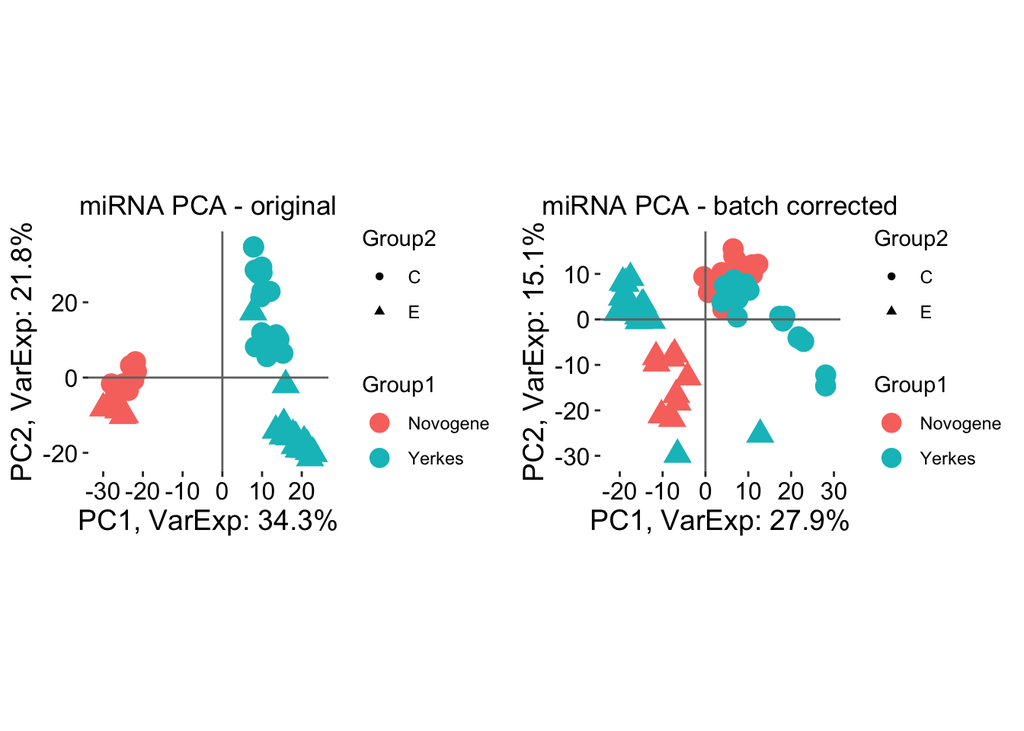

```r
#Remove known batch effect (Yerkes vs. Novogene with limma)

plotPCA = function(df, group1, group2, title){ # PCA plot function
  PCA = prcomp(t(df), scale = FALSE)
  percentVar = round(100*PCA$sdev^2/sum(PCA$sdev^2),1)
  sd_ratio = sqrt(percentVar[2] / percentVar[1])
  dataGG = data.frame(PC1 = PCA$x[,1],
                     PC2 = PCA$x[,2],
                     Sample = colnames(df),
                     Group1 = group1,
                     Group2 = group2)
  ggplot(dataGG, aes(PC1, PC2)) +
  geom_point(aes(colour = Group1, shape = Group2, size = 2)) +
  guides(size = FALSE, color = guide_legend(override.aes = list(size=4)))+
  ggtitle(title) +
  #scale_color_manual(values=c(child="#5D3C91", infant="#45989B", neonate ="#EFB931"))+
  xlab(paste0("PC1, VarExp: ", percentVar[1], "%")) +
  ylab(paste0("PC2, VarExp: ", percentVar[2], "%")) +
  theme(plot.title = element_text(hjust = 0.5),
        panel.grid.major = element_blank(),
        panel.grid.minor = element_blank(),
        panel.background = element_rect(fill = "white", colour = "white", size = 0.5, linetype = "solid"),
        axis.text.x = element_text(color = "black", size = 12),
        axis.text.y = element_text(color = "black", size = 12),
        axis.title.x = element_text(color="black", size=14),
        axis.title.y = element_text(color="black", size=14),
        legend.key = element_blank()) +
  coord_fixed(ratio = sd_ratio) +
  xlim(round(min(dataGG$PC1),0)-1, round(max(dataGG$PC1),0)+1) +
  ylim(round(min(dataGG$PC2),0)-1, round(max(dataGG$PC2),0)+1) +
  theme(aspect.ratio=1) +
  geom_hline(yintercept=0, color = "gray45", size=0.5) +
  geom_vline(xintercept=0, color = "gray45", size=0.5)
}
library(gridExtra)
grid.arrange(plotPCA(dge_logcpm, coldata$Batch, coldata$Type, "miRNA PCA - original"),
             plotPCA(dge_logcpm_batchcorr, coldata$Batch, coldata$Type, "miRNA PCA - batch corrected"), nrow = 1)
```

```r
EVbatch = coldata[coldata$Type == "E",6]
cellbatch = coldata[coldata$Type == "C",6]

#grid.arrange(plotPCA(as.data.frame(dge_logcpm) %>% dplyr::select(starts_with("E")), EVbatch, rep("EV",length(EVbatch)), "miRNA EV PCA - original"), plotPCA(as.data.frame(dge_logcpm_batchcorr) %>% dplyr::select(starts_with("E")), EVbatch, rep("EV",length(EVbatch)), "miRNA EV PCA - batch corrected"), plotPCA(as.data.frame(dge_logcpm) %>% dplyr::select(starts_with("C")), cellbatch, rep("Cell",length(cellbatch)), "miRNA Cell PCA - original"), plotPCA(as.data.frame(dge_logcpm_batchcorr) %>% dplyr::select(starts_with("C")), cellbatch, rep("Cell",length(cellbatch)), "miRNA Cell PCA - batch corrected"))
```

# Perform Variance Partition - before and after batch correction

1. VariancePartition: fit linear mixed model and find variance from patient variables –> Patient, Batch (Novogene or Yerkes), Type (Cell or EV), Sex, log(Age in months)

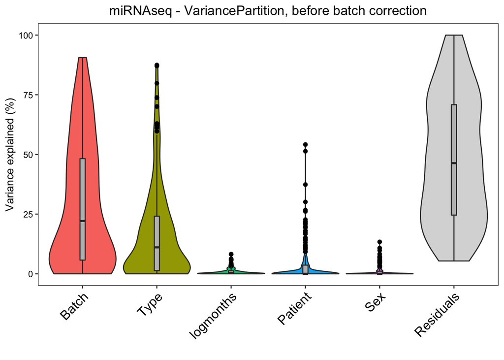

```r
library(variancePartition)
# Variance Partition
formula_miR = ~ (1|Patient) + (1|Batch) + (1|Type) + (1|Sex) + logmonths
# before batch correction
varPart_before = fitExtractVarPartModel(dge_logcpm, formula_miR, coldata)
plotVarPart(sortCols(varPart_before), label.angle = 45) + ggtitle("miRNAseq - VariancePartition, before batch correction") +
  theme(panel.grid.major = element_blank(), panel.grid.minor = element_blank())
```

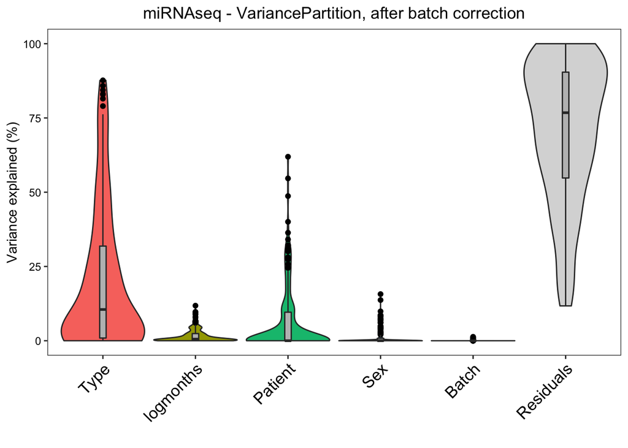

```r
# after batch correction
varPart_after = fitExtractVarPartModel(dge_logcpm_batchcorr, formula_miR, coldata)
plotVarPart(sortCols(varPart_after), label.angle = 45) + ggtitle("miRNAseq - VariancePartition, after batch correction") +
  theme(panel.grid.major = element_blank(), panel.grid.minor = element_blank())
```

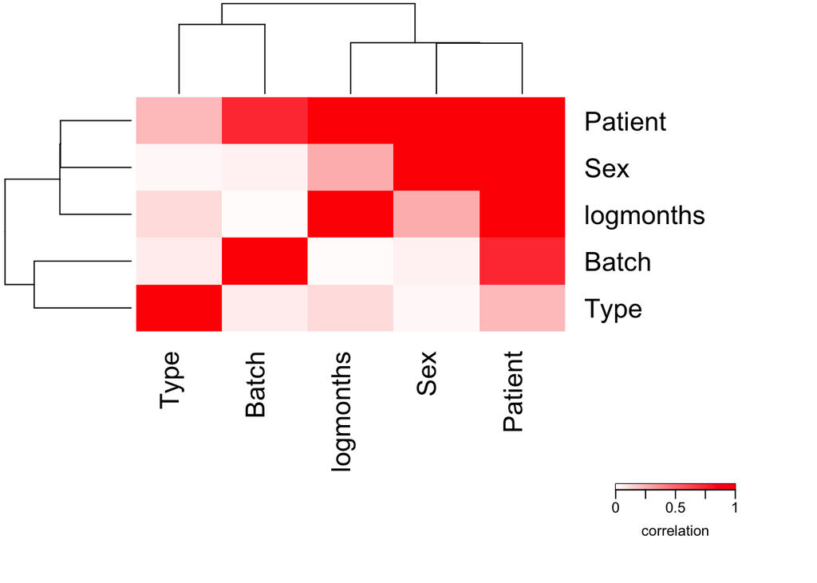

```r
# Correlation between pairs of variables (CCA, canonical correlation analysis)
plotCorrMatrix(canCorPairs(formula = ~ Patient + Batch + Type + Sex + logmonths, coldata))
```

# PCA of miRNA data

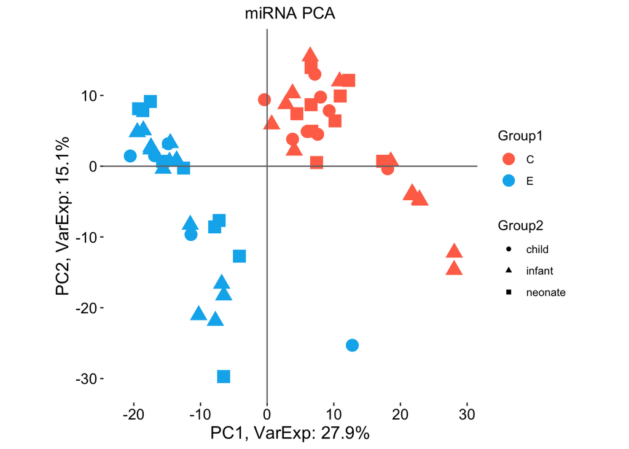

```r
plotPCA(dge_logcpm_batchcorr, coldata$Type, coldata$`Age Group`,"miRNA PCA") + scale_color_manual(values=c(C="coral1", E="deepskyblue2"))
```

# DEA: CPC vs. CPC-EV

- Use edgeR and limma/dream
1. Clean data - remove unpaired items: C938, C1048, C1092; C894 and E894 –> sex not known for this patient
2. dream approach in variancePartition, patient = random variable

```r
# Filter
coldata2 = coldata %>% filter(!rownames(coldata) %in% c("C894","E894", "C938","C1048","C1092"))
str(coldata2)
```

```
## 'data.frame':    52 obs. of  7 variables:
##  $ Type        : Factor w/ 2 levels "C","E": 1 1 1 1 1 1 1 1 1 1 ...
##  $ Patient     : Factor w/ 30 levels "894","896","902",..: 14 15 16 21 26 27 29 30 6 8 ...
##  $ Age (months): int  12 6 6 36 3 5 3 0 0 0 ...
##  $ Age Group   : Factor w/ 3 levels "child","infant",..: 1 2 2 1 2 2 2 3 3 3 ...
##  $ Sex         : Factor w/ 2 levels "F","M": 2 1 2 2 2 1 2 1 1 2 ...
##  $ Batch       : Factor w/ 2 levels "Novogene","Yerkes": 1 1 1 1 1 1 1 1 1 1 ...
##  $ logmonths   : num  1.079 0.778 0.778 1.556 0.477 ...
```

```r
dge_logcpm_batchcorr2 = as.data.frame(dge_logcpm_batchcorr) %>% dplyr::select(-c("C894","E894", "C938","C1048","C1092"))

dge2 = DGEList(counts = merged_filteredcounts %>% dplyr::select(-c("C894","E894", "C938","C1048","C1092")), group = coldata2$Type)
keep2 = filterByExpr(dge2); table(keep2) # Use filterByExpr with default params
```

```
## keep2
## TRUE
##  193
```

```r
dge2 = calcNormFactors(dge2, method = "TMM")
dge2$samples
```

```
##       group lib.size norm.factors
## C1004     C  2825875        0.512
## C1006     C  1616248        0.574
## C1007     C  3279589        0.697
## C1063     C  3848324        0.684
## C1097     C  3076827        0.563
## C1099     C  2713544        0.593
## C2013     C   554698        0.629
## C2016     C  2649121        0.550
## C925      C  1954460        0.620
## C930      C  4134077        0.684
## C975      C   762746        0.664
## C924      C   642268        0.906
## C1010     C   785570        0.828
## C1066     C   709334        0.807
## C956      C   896034        0.661
## C957      C  1477747        0.634
## C903      C  1944694        0.565
## C926      C  1229017        0.505
## C1045     C  1867151        0.769
## C902      C  1452273        0.558
## C1050     C  1150919        0.979
## C1095     C  1826076        0.781
## C896      C   813903        0.731
## C1100     C  1540946        0.772
## C985      C  3076073        0.785
## C1083     C  4247019        0.679
## E1004     E   106557        0.881
## E1006     E   180523        0.746
## E1045     E   232644        0.677
## E1050     E   124958        0.803
## E1095     E    95740        0.492
## E1099     E   159555        0.656
## E2013     E    58555        0.827
## E903      E   140363        0.744
## E956      E    76765        0.745
## E902      E    93089        1.647
## E896      E   241505        1.283
## E1097     E    56327        1.851
## E1063     E     9898        1.043
## E1066     E    23701        2.976
## E930      E    57317        2.830
## E1007     E    48898        2.793
## E924      E   116116        1.595
## E1010     E    88235        2.285
## E975      E    88500        1.428
## E1083     E    20952        4.111
## E925      E    27342        3.986
## E957      E    90524        1.918
## E926      E    33832        3.506
## E2016     E    37331        3.909
## E1100     E   252928        1.754
## E985      E   156770        1.534
```

```r
# Dream Approach
# variable tested (Type) must be a fixed effect
form = ~ Batch + Type + Sex + logmonths + (1|Patient)
# estimate weights using linear mixed model of dream
vobjdream = voomWithDreamWeights(dge2, form, coldata2)
# fit the model to each gene - Satterthwaite approx for hypot.test
fit = dream(vobjdream, form, coldata2)
fit = eBayes(fit)
topTable(fit, coef = "TypeE", number = 20) # Get results of hypothesis test on coefficients of interest
```

```
##                 logFC AveExpr      t  P.Value adj.P.Val z.std
## hsa-miR-486-5p   7.49    7.44  13.13 2.44e-17  2.88e-15  8.47
## hsa-miR-24-3p   -2.13   12.73 -13.01 3.41e-17  2.88e-15 -8.43
## hsa-let-7d-3p    2.91    9.18  18.08 4.47e-17  2.88e-15  8.40
## hsa-miR-21-5p   -2.48   14.49 -12.47 1.61e-16  7.78e-15 -8.25
## hsa-let-7f-5p   -2.82   15.24 -19.53 5.36e-16  2.07e-14 -8.10
## hsa-miR-29b-3p  -4.05    9.01 -16.91 3.23e-15  1.04e-13 -7.88
## hsa-miR-103a-3p -2.45   11.26 -16.59 9.44e-15  2.60e-13 -7.75
## hsa-miR-27b-3p  -2.73   12.77 -15.20 6.00e-14  1.45e-12 -7.51
## hsa-miR-29a-3p  -2.61   11.30 -10.30 1.22e-13  2.53e-12 -7.41
## hsa-miR-379-5p  -3.39   10.79 -15.01 1.31e-13  2.53e-12 -7.41
## hsa-miR-16-5p   -2.12   12.27 -10.24 1.50e-13  2.63e-12 -7.39
## hsa-miR-30a-5p  -3.16   11.13 -13.54 4.43e-13  7.13e-12 -7.24
## hsa-miR-152-3p  -1.98   10.20 -13.35 5.48e-13  8.13e-12 -7.21
## hsa-let-7e-5p   -2.93   12.82 -15.58 8.67e-13  1.20e-11 -7.15
## hsa-miR-1180-3p  4.27    6.77   9.65 9.98e-13  1.28e-11  7.13
## hsa-let-7g-5p   -1.28   12.49  -9.39 2.36e-12  2.85e-11 -7.01
## hsa-miR-27a-3p  -3.28    9.65  -9.21 4.26e-12  4.83e-11 -6.93
## hsa-miR-26b-5p  -1.61   10.70  -9.19 4.52e-12  4.85e-11 -6.92
## hsa-miR-31-5p   -3.24    9.09 -11.64 1.22e-11  1.24e-10 -6.78
## hsa-miR-92b-5p   4.15    6.65   8.29 9.50e-11  9.16e-10  6.47
```

```r
fit$design
```

```
##       (Intercept) BatchYerkes TypeE SexM logmonths
## C1004           1           0     0    1     1.079
## C1006           1           0     0    0     0.778
## C1007           1           0     0    1     0.778
## C1063           1           0     0    1     1.556
## C1097           1           0     0    1     0.477
## C1099           1           0     0    0     0.699
## C2013           1           0     0    1     0.477
## C2016           1           0     0    0     0.000
## C925            1           0     0    0     0.000
## C930            1           0     0    1     0.000
## C975            1           1     0    1     0.778
## C924            1           1     0    1     0.301
## C1010           1           1     0    1     0.301
## C1066           1           1     0    0     0.778
## C956            1           1     0    0     0.699
## C957            1           1     0    1     0.845
## C903            1           1     0    0     0.000
## C926            1           1     0    1     1.146
## C1045           1           1     0    0     0.000
## C902            1           1     0    1     1.681
## C1050           1           1     0    0     0.000
## C1095           1           1     0    1     0.477
## C896            1           1     0    0     1.079
## C1100           1           1     0    0     0.000
## C985            1           1     0    1     0.000
## C1083           1           1     0    0     0.000
## E1004           1           0     1    1     1.079
## E1006           1           0     1    0     0.778
## E1045           1           0     1    0     0.000
## E1050           1           0     1    0     0.000
## E1095           1           0     1    1     0.477
## E1099           1           0     1    0     0.699
## E2013           1           0     1    1     0.477
## E903            1           0     1    0     0.000
## E956            1           0     1    0     0.699
## E902            1           1     1    1     1.681
## E896            1           1     1    0     1.079
## E1097           1           1     1    1     0.477
## E1063           1           1     1    1     1.556
```

[output cut: 12 more lines]

```
## E985            1           1     1    1     0.000
## attr(,"assign")
## [1] 0 1 2 3 4
## attr(,"contrasts")
## attr(,"contrasts")$Batch
## [1] "contr.treatment"
##
## attr(,"contrasts")$Type
## [1] "contr.treatment"
##
## attr(,"contrasts")$Sex
## [1] "contr.treatment"
##
## attr(,"msgScaleX")
## character(0)
```

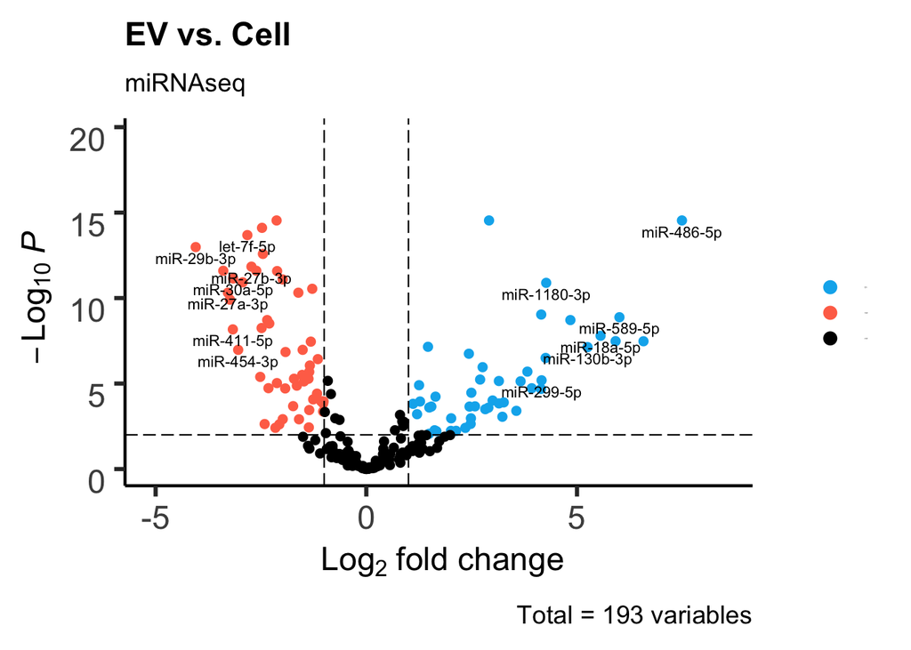

```r
res = topTable(fit, coef = "TypeE", number = 193)
topCell = str_sub(rownames(res[head(order(res$logFC),10),]),5,-1)
topEV = str_sub(rownames(res[head(order(res$logFC,decreasing = T),10),]),5,-1)

keyvals = ifelse((res$logFC < -1 & res$adj.P.Val<0.01), 'coral1', ifelse((res$logFC > 1 & res$adj.P.Val<0.01), 'deepskyblue2','black'))
keyvals[is.na(keyvals)] <- 'black'
names(keyvals)[keyvals == 'deepskyblue2'] <- 'EV'
names(keyvals)[keyvals == 'black'] <- 'mid'
names(keyvals)[keyvals == 'coral1'] <- 'Cell'

library(EnhancedVolcano)
EnhancedVolcano(res,
                lab = str_sub(rownames(res),5,-1),
                x = 'logFC',
                y = 'adj.P.Val',
                pCutoff = 0.01,
                FCcutoff = 1.0,
                selectLab =  c(topCell,topEV),
                title = 'EV vs. Cell',
                subtitle = "miRNAseq",
                legendPosition = 'right',
                legendLabSize = 1,
                colAlpha = 1,
                gridlines.major = FALSE,
                gridlines.minor = FALSE,
                #xlim = c(-4.5,8.5),
                #ylim = c(0,50),
                colCustom = keyvals,
                legendIconSize = 3)
```

# Table of DE miRNAs

```r
library(sjPlot)

up = res[(res$logFC>1 & res$adj.P.Val<0.05),] %>% arrange(-logFC); dim(up)
```

```
## [1] 56  6
```

```r
down = res[(res$logFC<(-1) & res$adj.P.Val<0.05),] %>% arrange(logFC); dim(down)
```

```
## [1] 53  6
```

```r
up$RNA = rownames(up)
down$RNA = rownames(down)

signif.num <- function(x) {symnum(x, corr = FALSE, na = FALSE, legend = FALSE,
                                  cutpoints = c(0, 1e-10, 1e-5, 1e-2, 0.1, 1),
                                  symbols = c("***", "**", "*", ".", " "))}

up$padj = signif.num(up$adj.P.Val)
down$padj = signif.num(down$adj.P.Val)
colnames(up)[1] = "Log2(EV/Cell)"
colnames(down)[1] = "Log2(Cell/EV)"

up.2 = subset(arrange(up, -`Log2(EV/Cell)`), select=c(RNA,`Log2(EV/Cell)`, padj))
down.2 = subset(arrange(down, `Log2(Cell/EV)`), select=c(RNA,`Log2(Cell/EV)`, padj))

bof = cbind(head(up,25)%>% dplyr::select(c("RNA","Log2(EV/Cell)","padj")), head(down,25) %>% dplyr::select(c("RNA","Log2(Cell/EV)","padj")))
bof$`Log2(Cell/EV)` = -1*(bof$`Log2(Cell/EV)`)

#tab_df(bof, alternate.rows = T, title = "RNAs preferentially released to EV and retained in cell", col.header = c("RNA", "Log2(EV/Cell)", "padj", "RNA", "Log2(Cell/EV)", "padj"), footnote = "*p < 0.01, **p < 1e-5, ***p < 1e-10", show.footnote = T, file="/Volumes/davis-lab/Jess Hoffman/11. Big Seq/11. For Paper/FinalR/top25table_miR.doc")
```

# Find Gene Targets of DE miRNAs

```r
# Get targets
up = res[(res$logFC>1 & res$adj.P.Val<0.05),] %>% arrange(-logFC); dim(up)
```

```
## [1] 56  6
```

```r
down = res[(res$logFC<(-1) & res$adj.P.Val<0.05),] %>% arrange(logFC); dim(down)
```

```
## [1] 53  6
```

```r
db = read.csv("~/Desktop/hsa_miRTarbase.csv")

target = data.frame()
for (i in 1:nrow(up)) {
  miR = rownames(up)[i]
  newtarget = db[(db$miRNA == as.character(miR) & db$num.exps>=4),c(1,3,5)]
  target = rbind(target, newtarget)}
target$direction = rep("upregulated in CPC-EV", nrow(target))
tEV = target

target = data.frame()
for (i in 1:nrow(down)) {
  miR = rownames(down)[i]
  newtarget = db[(db$miRNA == as.character(miR) & db$num.exps>=4),c(1,3,5)]
  target = rbind(target, newtarget)}
target$direction = rep("upregulated in CPC", nrow(target))

#write.csv(rbind(tEV,target) %>% distinct(), "/Users/jhoff18/Desktop/targets.csv")
```

# DE miRNA families

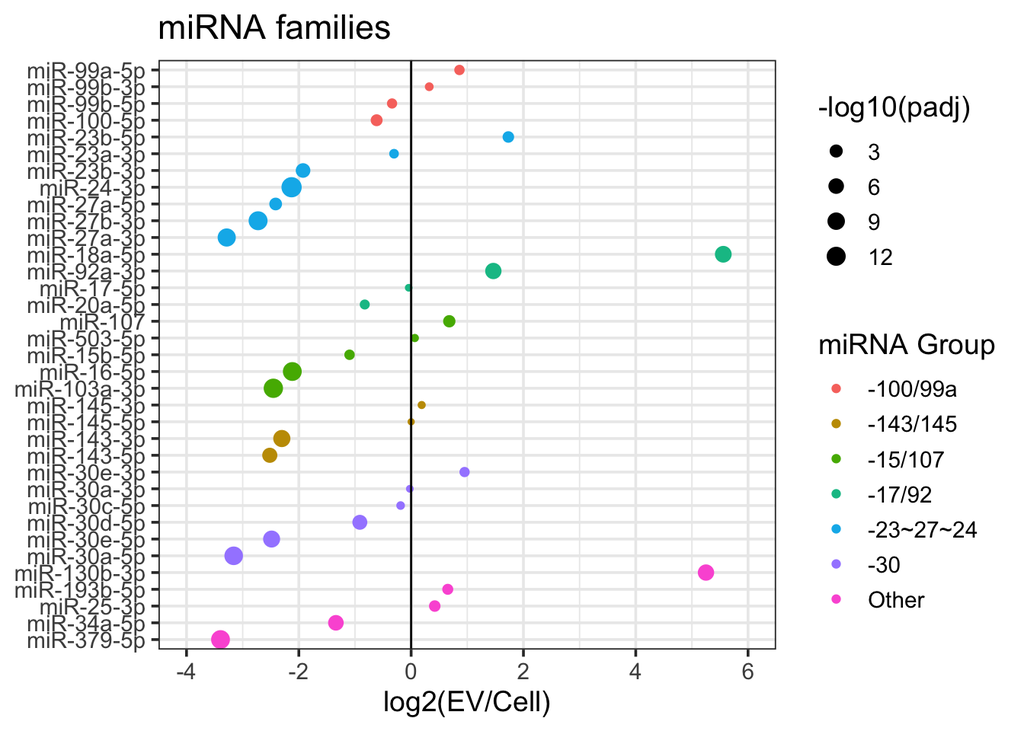

```r
f30 = res[grepl('-30', rownames(res)),] %>% arrange(logFC); f30$Group = rep("-30",nrow(f30))
f143_145 = res[grepl('-143|-145', rownames(res)),]%>% arrange(logFC); f143_145$Group = rep("-143/145",nrow(f143_145))
f15_107 = res[grepl('miR-15a-5p|miR-15b-5p|miR-16-5p|miR-103a-3p|miR-107|miR-195-5p|miR-424-5p|miR-497-5p|miR-503-5p|miR-646', rownames(res)),]%>% arrange(logFC); f15_107$Group = rep("-15/107",nrow(f15_107)) # Finnerty 2010
f17_92 = res[grepl('miR-17|miR-18a|miR-19a|miR-20a|miR-19b-1|miR-92a', rownames(res)),]%>% arrange(logFC); f17_92$Group = rep("-17/92",nrow(f17_92))
f23_24_27 = res[grepl('miR-23a|miR-27a|miR-24-2|miR-23b|miR-27b|miR-24-1|miR-24', rownames(res)),]%>% arrange(logFC); f23_24_27$Group = rep("-23~27~24",nrow(f23_24_27))
f99_100 = res[grepl('miR-99a|miR-99b|miR-100', rownames(res)),]%>% arrange(logFC); f99_100$Group = rep("-100/99a",nrow(f99_100))
other = res[grepl('miR-379|miR-34a|miR-25|miR-193b|miR-130b', rownames(res)),]%>% arrange(logFC); other$Group = rep("Other",nrow(other))
mirfam = rbind(other,f30,f143_145,f15_107,f17_92,f23_24_27,f99_100);mirfam$miRNA = str_sub(rownames(mirfam),5,-1)

ggplot(mirfam, aes(x = logFC, y = factor(miRNA, level = miRNA))) +
  geom_point(aes(size = -1*log10(adj.P.Val), color = Group)) +
  theme_bw(base_size = 14) +
  geom_vline(xintercept = 0, size =0.5, color = "black")+
  ylab(NULL) +
  scale_size(breaks = seq(0,15,3), range = c(1,4)) +
  ggtitle("miRNA families")+
  scale_x_continuous(name ="log2(EV/Cell)", limits=c(-4,6))+
  labs(color='miRNA Group', size = '-log10(padj)')
```

# Data-mining

```r
library(miRBaseConverter)
#read in tsv files
setwd("/Volumes/davis-lab/Jess Hoffman/11. Big Seq/10. Other EV:Cell data")
filelist = list.files(pattern = ".*.txt")
datalist = lapply(filelist, function(x)read.table(x, header=T,sep = '\t'))

otherGEO = data.frame()
for (i in 1:length(datalist)) {
  currentset = as.data.frame(datalist[i])
  nam = parse_number(filelist)[i]
  set = dplyr::select(currentset, c("miR","logFC","adj.P.Val"))
  set$name = rep(paste0("GSE",nam),nrow(set)) # set study geo name
  set = set %>% mutate_all(na_if,"")
  set = set %>% dplyr::filter(str_detect(miR, "^hsa")) %>% arrange(-logFC) # pick up hsa miRNAs only, sort by FC
  set$miR = gsub("r","R",set$miR) #capitalize R in miR
  set$miR = miRNAVersionConvert(set$miR, targetVersion = "v22")[2][,1]
  set = set %>% dplyr::filter(complete.cases(.))
  set$rank = 1:nrow(set)
  otherGEO = rbind(otherGEO, set)}
```

[output not shown]

[output cut: 82 more lines]

```r
dim(otherGEO)
```

```
## [1] 14452     5
```

```r
table(otherGEO$name)
```

```
##
## GSE103708 GSE125030  GSE27997  GSE45289  GSE48908  GSE48909  GSE48910  GSE58027
##       869      3736       343       365       368       368       368       307
##  GSE60714  GSE60715  GSE76449
##      1069      2923      3736
```

```r
# Our dataset
mymiRs = res %>% mutate(miR = rownames(res)) %>% arrange(-logFC) %>% dplyr::select(c("miR","logFC","adj.P.Val"))
mymiRs$name = rep("me",nrow(mymiRs))
mymiRs$rank = 1:nrow(mymiRs)
top15 = rbind(mymiRs[1:15,], mymiRs[179:193,])
# Merge sets
studies = (paste0("GSE", parse_number(filelist)))
dm = data.frame(matrix(NA, nrow = nrow(top15), ncol = length(studies)))
colnames(dm) = studies
dm = data.frame(top15%>% dplyr::select(rank), dm)

for (i in 1:nrow(dm)) {
  m = row.names(dm)[i]
  o = otherGEO[grep(m, otherGEO$miR),]
  for (i in 1:nrow(o)) {
    ranki = o[i,5]
    studyname = o[i,4]
    dm[which(rownames(dm) == m), which(colnames(dm) == studyname)] = ranki}}
dm
```

```
##                 rank GSE103708 GSE125030 GSE27997 GSE45289 GSE48908 GSE48909
## hsa-miR-486-5p     1        99       463       NA        6      182       12
## hsa-miR-203a-3p    2       381      2494      238       25      202      336
## hsa-miR-589-5p     3        NA      3171       NA      226      241      238
## hsa-miR-122-5p     4       233       613       NA       11        1      146
## hsa-miR-18a-5p     5       675      3634       NA      317      329      307
## hsa-miR-130b-3p    6       816      3629      325      347      356      362
## hsa-miR-320c       7        71      3512       NA       NA       NA       NA
## hsa-miR-1180-3p    8        76      3612       NA       NA       NA       NA
## hsa-miR-760        9       140      3434       NA       NA       NA       NA
## hsa-miR-299-5p    10       488      1712       NA      165       77       41
## hsa-miR-92b-5p    11        NA        37      248       NA       NA       NA
## hsa-miR-339-3p    12       249      3593      117      250      248      250
## hsa-miR-125a-3p   13        79      3682       NA      281       55      151
## hsa-miR-494-3p    14       853      3500       NA      242       20        8
## hsa-miR-501-3p    15       716      3656       NA        3      245      273
## hsa-miR-103a-3p  179       578      3673       NA      303      366        1
## hsa-miR-21-5p    180       598      3564       NA      353      364      352
## hsa-miR-30e-5p   181       524      3591       NA       NA       NA       NA
## hsa-miR-143-5p   182        NA      2370       98       NA       NA       NA
## hsa-miR-29a-3p   183       759      3568       NA      221      239      224
## hsa-miR-27b-3p   184       594      3611       NA      339      347      350
## hsa-let-7f-5p    185       600      3652       NA      171      338        5
## hsa-let-7e-5p    186       595      3672       NA       NA       NA       NA
## hsa-miR-454-3p   187       330      3563       NA      192      209      140
## hsa-miR-30a-5p   188       547      3532      285       NA       NA       NA
## hsa-miR-411-5p   189        NA      2647       72      293      179      162
## hsa-miR-31-5p    190       457      3597       NA       39      296      236
## hsa-miR-27a-3p   191       774      3562      283      328      327      343
## hsa-miR-379-5p   192       659      3353       40      346       17      155
## hsa-miR-29b-3p   193       824      3716      341      223      311      257
##                 GSE48910 GSE58027 GSE60714 GSE60715 GSE76449
## hsa-miR-486-5p        19       NA      217     2373     1007
## hsa-miR-203a-3p      212       NA      661     1258     3405
## hsa-miR-589-5p       188       NA     1031     1099     2839
## hsa-miR-122-5p       343       NA      702     2474     1608
## hsa-miR-18a-5p       330       NA      416     1980     3658
## hsa-miR-130b-3p      336       NA      118     2687     3538
## hsa-miR-320c          NA       NA      880       NA     2424
## hsa-miR-1180-3p       NA       NA     1044     1588     3652
## hsa-miR-760           NA       13        3        7     3195
## hsa-miR-299-5p       100       NA      264       NA     1766
## hsa-miR-92b-5p        NA       49      596     2573      871
## hsa-miR-339-3p       232       NA      813       NA     3600
## hsa-miR-125a-3p       73      263       70       NA     3441
## hsa-miR-494-3p         8      261     1069       98     3129
## hsa-miR-501-3p       307       NA      401       NA     3635
## hsa-miR-103a-3p      326      283      732       NA     3698
## hsa-miR-21-5p        339      306      975     2791     3474
## hsa-miR-30e-5p        NA      262      906     1707     3663
## hsa-miR-143-5p        NA       NA      438     1596     2134
## hsa-miR-29a-3p       213       NA       38     2847     3624
## hsa-miR-27b-3p       351       NA      791       NA     3618
## hsa-let-7f-5p         52      295      602       NA     3731
## hsa-let-7e-5p         NA       NA       NA       NA     3734
## hsa-miR-454-3p        54      230      883     1377     3183
## hsa-miR-30a-5p        NA       NA      758     1105     3549
## hsa-miR-411-5p       126      220      159      432     3017
## hsa-miR-31-5p        102       NA     1014     1495     3692
## hsa-miR-27a-3p       324       NA      397     2721     3569
## hsa-miR-379-5p        15      233      608      739     3542
## hsa-miR-29b-3p       247       NA      315       NA     3617
```

```r
print(colSums(is.na(dm))) #NAs of 30 miRNAs
```

```
##      rank GSE103708 GSE125030  GSE27997  GSE45289  GSE48908  GSE48909  GSE48910
##         0         4         0        20         8         8         8         8
##  GSE58027  GSE60714  GSE60715  GSE76449
##        19         1        10         0
```

```r
# Create heatmap figure
library(tagcloud)
library(RColorBrewer)
dm = dm[,c(1,2,5,6,7,8,4,9,10,11,3,12)] # reorder columns
colnames(dm)
```

```
##  [1] "rank"      "GSE103708" "GSE45289"  "GSE48908"  "GSE48909"  "GSE48910"
##  [7] "GSE27997"  "GSE58027"  "GSE60714"  "GSE60715"  "GSE125030" "GSE76449"
```

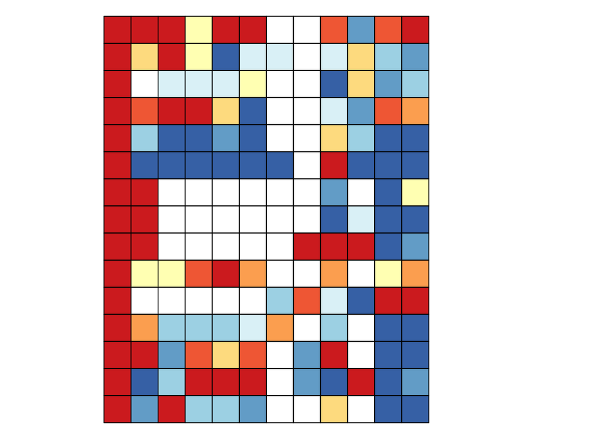

```r
t(sapply(dm, function(x) smoothPalette(x, pal= "RdYlBu"))[1:15,]) %>% scales::show_col(labels = F, ncol = 12)
```

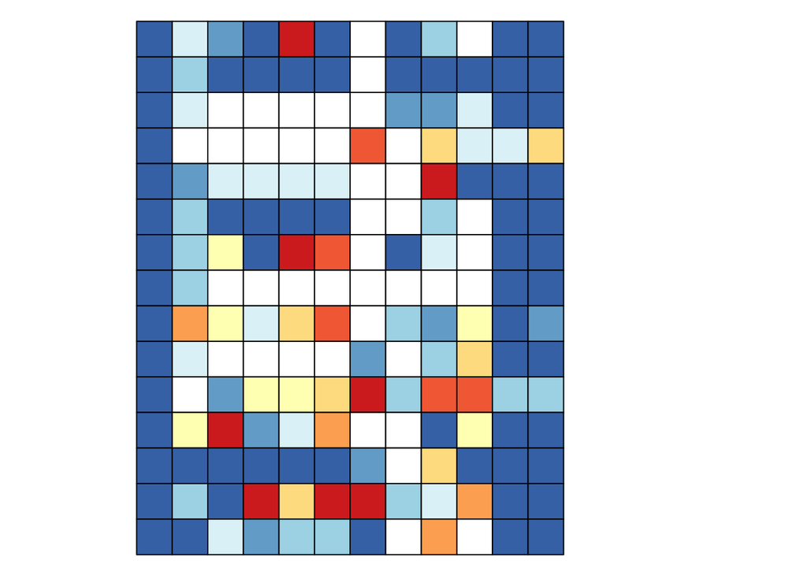

```r
t(sapply(dm, function(x) smoothPalette(x, pal= "RdYlBu"))[16:30,]) %>% scales::show_col(labels = F, ncol = 12)
```

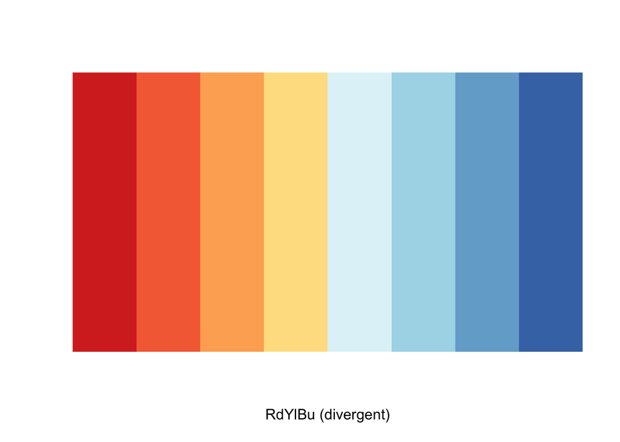

```r
# scale
display.brewer.pal(n = 8, name = 'RdYlBu')
```

# SVAseq

Note: Can’t compute latent variables with Patient covariate included in model –> Too many covariates. The matrix t(mod)*mod is singular, det~0 We will focus on DE model with patient random effect and mention surrogate variables in supplement Major revision: adjust for patient random effect in DE model. Minor/Moderate revision: estimate latent variables.

# Estimate surrogate variables (without patient covariate)

```r
dge_logcpm_batchcorr_sva2 = as.data.frame(dge_logcpm_batchcorr) %>% dplyr::select(-c("C894","E894", "C938","C1048","C1092"))

write.csv(coldata2,"/Users/jhoff18/Desktop/coldata2.csv")
coldata2 = read.csv("/Users/jhoff18/Desktop/coldata2.csv") %>% column_to_rownames("X")
  coldata2$Type = as.factor(coldata2$Type)
  coldata2$Batch = as.factor(coldata2$Batch)
  coldata2$Sex = as.factor(coldata2$Sex)
  coldata2$Patient = as.factor(coldata2$Patient)
write.csv(dge_logcpm_batchcorr_sva2,"/Users/jhoff18/Desktop/dge_logcpm_batchcorr_sva2.csv")
dge_logcpm_batchcorr_sva2 = read.csv("/Users/jhoff18/Desktop/dge_logcpm_batchcorr_sva2.csv") %>% column_to_rownames("X")

dge_logcpm_batchcorr_sva2[dge_logcpm_batchcorr_sva2<0] = 0
dge_logcpm_batchcorr_sva2 = data.matrix(dge_logcpm_batchcorr_sva2)

#estimate latent variables
mod = model.matrix(~ Type + logmonths + Sex, data = coldata2)
mod0 = model.matrix(~ 1, data = coldata2)
n.sv = num.sv(dge_logcpm_batchcorr_sva2, mod, method = "leek"); n.sv
```

```
## [1] 2
```

```r
svseq = svaseq(dge_logcpm_batchcorr_sva2, mod, mod0, n.sv = n.sv, B = 10, method = "irw")
```

```
## Number of significant surrogate variables is:  2
## Iteration (out of 10 ):1  2  3  4  5  6  7  8  9  10
```

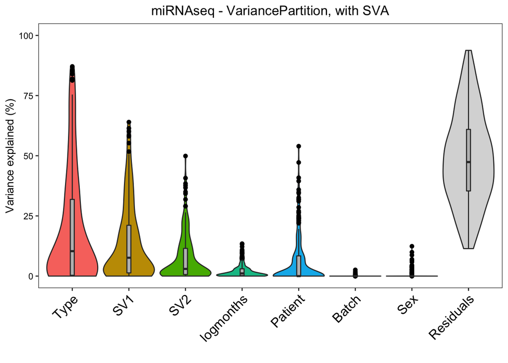

```r
# Add into model and run variance parition
mod.sv = cbind(mod, svseq$sv)
coldata2.sv = cbind(coldata2,svseq$sv)
colnames(coldata2.sv)[8:9] = c("SV1", "SV2")

varPart_sv = fitExtractVarPartModel(dge_logcpm_batchcorr_sva2, ~ (1|Patient) + (1|Batch) + (1|Type) + (1|Sex) + logmonths + SV1 + SV2, coldata2.sv)
plotVarPart(sortCols(varPart_sv), label.angle = 45) +
  ggtitle("miRNAseq - VariancePartition, with SVA") +
  theme(panel.grid.major = element_blank(), panel.grid.minor = element_blank())
```

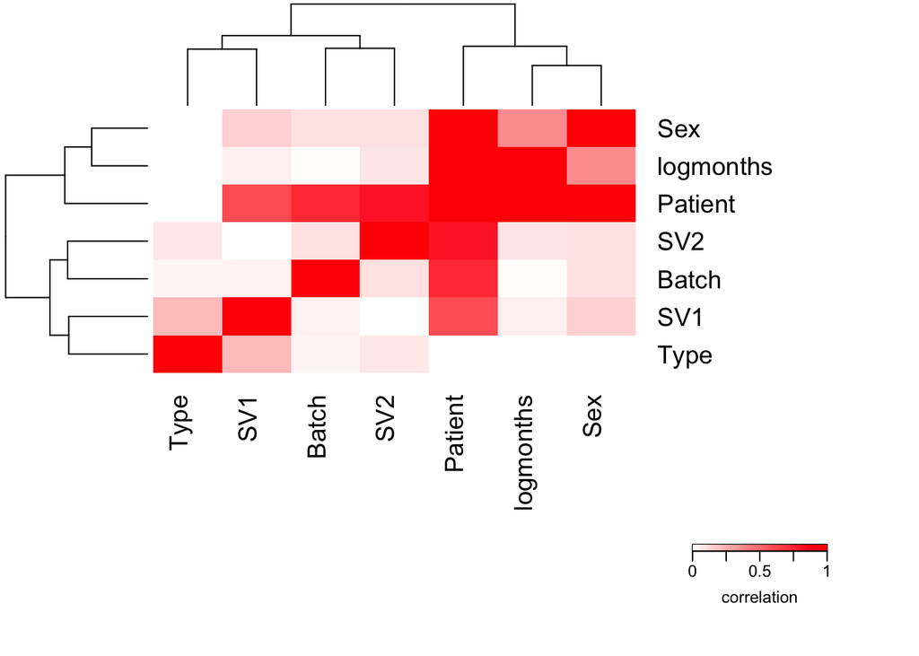

```r
# Correlation between pairs of variables (CCA, canonical correlation analysis)
plotCorrMatrix(canCorPairs(formula = ~  Patient + Batch + Type + Sex + logmonths + SV1 + SV2, coldata2.sv))
```

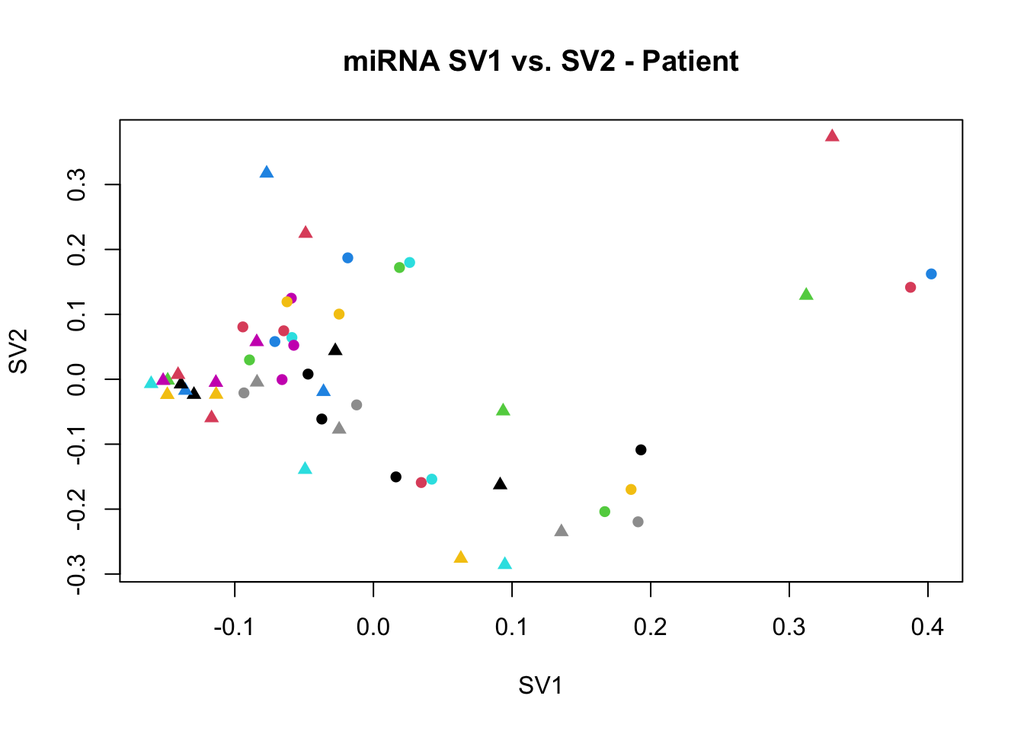

```r
#write.csv(canCorPairs(formula = ~ Patient + Batch + Type + Sex + logmonths + SV1 + SV2, coldata2.sv), "/Users/jhoff18/Desktop/SVAseq - Correlation of Co-variates.csv")

plot(svseq$sv[, 1], svseq$sv[, 2], col = coldata2.sv$Patient, pch = as.numeric(coldata2.sv$Type)+15, xlab = "SV1", ylab = "SV2", main = "miRNA SV1 vs. SV2 - Patient")
```